# Project Introduction

### 4.2 Use Lorenz curve to determine the model power in predicting the testing values

- random baseline: no prediction power
- oracle (grey): perfect prediction power
- oracle (green): predicting power using only exposure variable

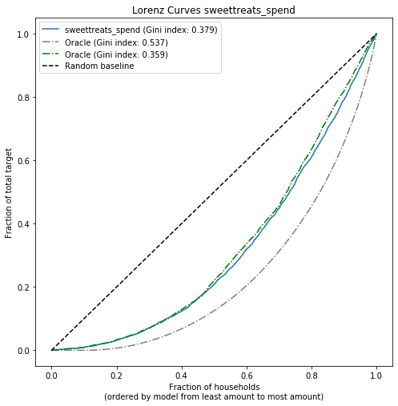

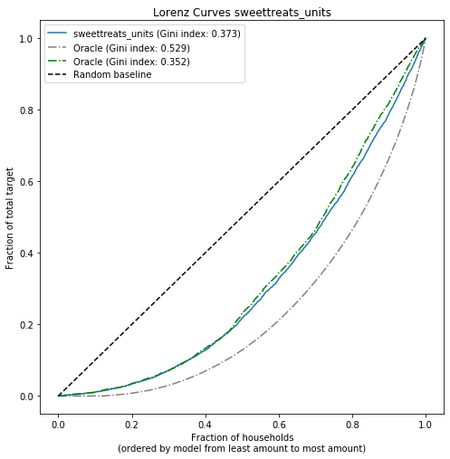

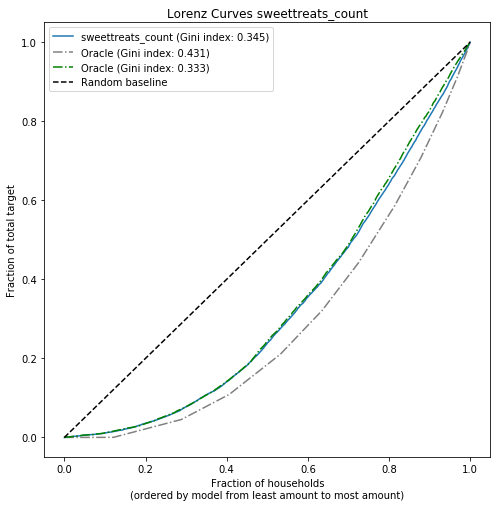

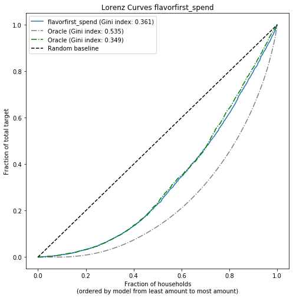

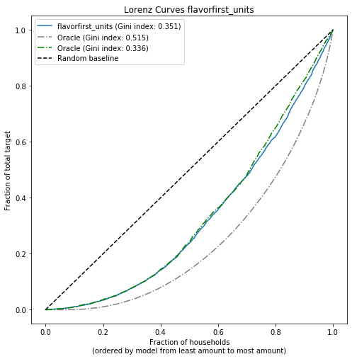

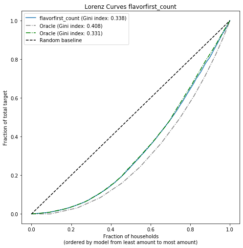

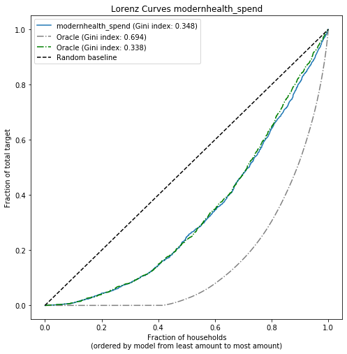

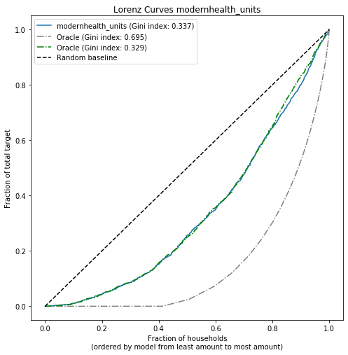

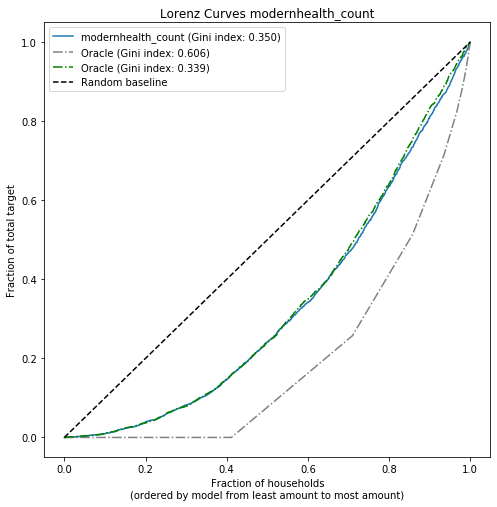

```python
def lorenz_curve(y_true, y_pred):
    y_true, y_pred = np.asarray(y_true), np.asarray(y_pred)

    # order samples by increasing predicted risk:
    ranking = np.argsort(y_pred)
    ranked_pure_premium = y_true[ranking]
    cumulated_claim_amount = np.cumsum(ranked_pure_premium)
    cumulated_claim_amount = cumulated_claim_amount/cumulated_claim_amount[-1]
    cumulated_samples = np.linspace(0, 1, len(cumulated_claim_amount))
    return cumulated_samples, cumulated_claim_amount

for var, model in model_dict.items():
    fig, ax = plt.subplots(figsize=(8, 8))

    # Get final prediction by multiplying model prediction with normalizing factor (exposure variable)
    y_pred_total = model.predict(X_test)*df_test[exposure_var].values

    #Curve for the model
    for label, y_pred in [(var, y_pred_total)]:
        ordered_samples, cum_claims = lorenz_curve(df_test[var], y_pred)
        gini = 1 - 2 * auc(ordered_samples, cum_claims)
        label += " (Gini index: {:.3f})".format(gini)
        ax.plot(ordered_samples, cum_claims, linestyle="-", label=label)

    # Oracle model1 (grey): y_pred == y_test
    ordered_samples, cum_claims = lorenz_curve(df_test[var], df_test[var])
    gini = 1 - 2 * auc(ordered_samples, cum_claims)
    label = "Oracle (Gini index: {:.3f})".format(gini)
    ax.plot(ordered_samples, cum_claims, linestyle="-.", color="gray",
            label=label)

    # Oracle model2 (green): Predict using exposure_var
    ordered_samples, cum_claims = lorenz_curve(df_test[var], df_test[exposure_var])
    gini = 1 - 2 * auc(ordered_samples, cum_claims)
    label = "Oracle (Gini index: {:.3f})".format(gini)
    ax.plot(ordered_samples, cum_claims, linestyle="-.", color="green",
            label=label)

    # Random baseline
    ax.plot([0, 1], [0, 1], linestyle="--", color="black",
            label="Random baseline")
    ax.set(
        title="Lorenz Curves "+var,
        xlabel=('Fraction of households\n'
                '(ordered by model from least amount to most amount)'),
        ylabel='Fraction of total target'
    )
    ax.legend(loc="upper left")
    plt.plot()
```

# Step5. Conclusion and suggestion

### Conclusion

- The model distinguishes high-value customers for a client's 3 product line segments: sweettreats, flavorfirst and modernhealth.
- Surprisingly the most predicting power came from the normalization variable: total units.
- I suspect total units serves as a proxy to the number of purchasing trips.
- While there is no reason to believe there is information leak from total spending features to segment spending, household demographic was ruled out from being a significant factor.
- There is likely latent features which is unseen in this project that determines this unexpected result.

### Suggestion

- Ideally I want to collect trip-wise data (the spending features of each trip), as month-wise data deosn't yield enough resolution.
- Once with the trip-wise data, it is possible to model the number of trips in a poisson regression.
- Alternatively with the trip-wise data, it is possible to model the segment spending in a tweedie regression.
- Future model can also log transform the spending or unit of segment spending as their histogram shows signs of exponential decay.
- It should not matter whether data aggregation to month or year was used, because poisson or tweedie regression should work for any time interval.